title: “hw3_Lanxiang_Li_ll2937” author: “Lanxiang Li” date: “October 21, 2014” output: html_document published:false tags:hw3

# A. Identify two surveys

I’m going to compare two waves (wave2 and wave6)in the World Values Survey in regards to the same survey question, simple but never out-dated: Are you happy?

# B.Describe the graph(s)

# C.Write down the target shape

1.year(wave):“1990-1994”, “2010-2014”; 2.country: “Spain”,“Japan”, “Mexico”…; 3.survey answer: “very happy”,“rather happy”,“not very happy”,“not at all happy”,“no answer”,“don’t know”; 4.proportion: the ratio of each level of happiness

# D. Write a script

## import the data

```r
setwd("~/Desktop/qmssviz/hw3")
load("/Users/carolineli/Desktop/qmssviz/hw3/WV2_Data_rdata_v_2014_04_28.rdata")
load("/Users/carolineli/Desktop/qmssviz/hw3/WV6_Data_rdata_v_2014_06_04.rdata")
dwv2 <- WV2_Data_rdata_v_2014_04_28
dwv6 <- WV6_Data_spss_v_2014_06_04
```

## check the data

```r
dim(dwv2)
```

```
## [1] 24558   426
```

```r
dim(dwv6)
```

```
## [1] 74042   381
```

```r
str(dwv2$v18)
```

```
##  int [1:24558] 3 2 1 3 1 1 -1 2 1 1 ...
```

```r
str(dwv6$V10)
```

```
##  int [1:74042] 2 2 2 2 1 2 2 2 2 1 ...
```

## Rename the Level of Happiness

```r
dwv2$v18[dwv2$v18==1] <- "very happy"
dwv2$v18[dwv2$v18==2] <- "rather happy"
dwv2$v18[dwv2$v18==3] <- "not very happy"
dwv2$v18[dwv2$v18==4] <- "not at all happy"
dwv2$v18[dwv2$v18==-1] <- "don't know"
dwv2$v18[dwv2$v18==-2] <- "no answer"
dwv2$v18[dwv2$v18==-3] <- "not applicable"
dwv6$V10[dwv6$V10==1] <- "very happy"
dwv6$V10[dwv6$V10==2] <- "rather happy"
dwv6$V10[dwv6$V10==3] <- "not very happy"
dwv6$V10[dwv6$V10==4] <- "not at all happy"
dwv6$V10[dwv6$V10==-1] <- "don't know"
dwv6$V10[dwv6$V10==-2] <- "no answer"
dwv6$V10[dwv6$V10==-3] <- "not applicable"
table(dwv6$V10)
```

```
##
##               -5       don't know        no answer not at all happy
##                4              464              228             2078
##   not very happy     rather happy       very happy
##             9290            38105            23873
```

```r
table(dwv2$v18)
```

```
##
##       don't know        no answer not at all happy   not very happy
##              529               60              805             5527
##     rather happy       very happy
##            12333             5304
```

## selecting data from 6 countries

```r
dwv2_new <- subset(dwv2,select=c("v1","v18","v2"),v2==156|v2==392|v2==410|v2==484|v2==566|v2==724)
dwv6_new <- subset(dwv6,select=c("V1","V10","V2"),V2==156|V2==392|V2==410|V2==484|V2==566|V2==724)
```

## Rename the countries

```r
dwv2_new$v2[dwv2_new$v2==156] <- "China"
dwv2_new$v2[dwv2_new$v2==392] <- "Japan"
dwv2_new$v2[dwv2_new$v2==410] <- "South Korea"
dwv2_new$v2[dwv2_new$v2==484] <- "Mexico"
dwv2_new$v2[dwv2_new$v2==566] <- "Nigeria"
dwv2_new$v2[dwv2_new$v2==724] <- "Spain"
dwv6_new$V2[dwv6_new$V2==156] <- "China"
dwv6_new$V2[dwv6_new$V2==392] <- "Japan"
dwv6_new$V2[dwv6_new$V2==410] <- "South Korea"
dwv6_new$V2[dwv6_new$V2==484] <- "Mexico"
dwv6_new$V2[dwv6_new$V2==566] <- "Nigeria"
dwv6_new$V2[dwv6_new$V2==724] <- "Spain"
```

## rename the columns

```r
colnames(dwv2_new) <-c("year","happiness","country")
colnames(dwv6_new) <-c("year","happiness","country")
dwv2_new$year <-"1992"
dwv6_new$year <-"2012"
```

## combine the two waves

```r
combine<-rbind(dwv2_new, dwv6_new)
dim(combine)
```

```
## [1] 18195     3
```

# E.Make it actually make your graph.

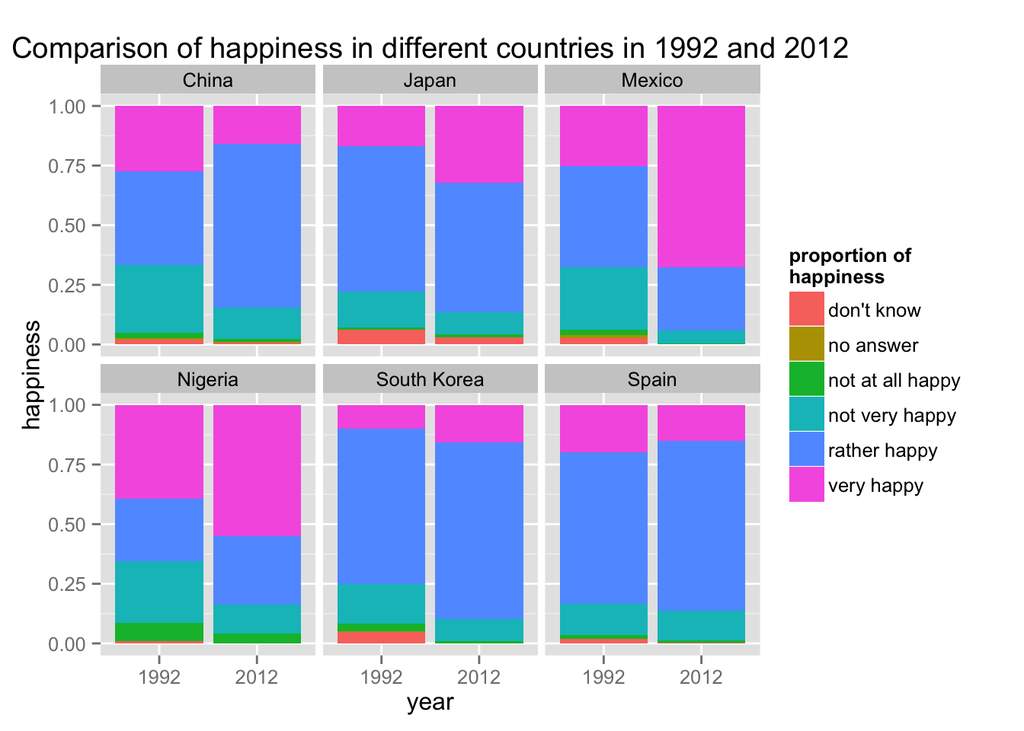

```r
library(ggplot2)
ggplot(combine, aes(x=year, fill=happiness)) + geom_bar(position="fill", binwidth=40) + facet_wrap(~country) + xlab("year") + ylab("happiness") + ggtitle("Comparison of happiness in different countries in 1992 and 2012") + scale_fill_discrete(name="proportion of\nhappiness")
```

## Summary:

From the graph, we can see that in some countries, there are more people feeling very happy(such as Mexico, Nigeria and South Korea), while in some countries there’s a decrease. We can get similar conclusions such as differences in two waves in different countries from the gragh.

# F&G. write funciton calls

## lookatdata <- function(data=d)

{ head(d) dim(d) view(d) }

## selectcolumns <- function(data)

{ data <- subset(data,select=c(“v1”,“v18”,“v2”),v2==156|v2==392|v2==410|v2==484|v2==566|v2==724) }

## combinedata <- funciton(data1, data2)

{ rbind(data1, data2) }

## renamecolumn <- function(data)

{ colnames(data) <- c(“year”,“happiness”,“country”) }